# Reproducible Research - Peer Reviewed Assignment 01

LALIT KUMAR JIWANI

August 5, 2016

```r
library(dplyr)
library(ggplot2)
library(Hmisc)
```

## Loading and preprocessing the data

```r
if(!file.exists('activity.csv')){
  unzip('repdata_data_activity.zip')
}

data_pac <- read.csv("activity.csv") ##data about Personal movement using ACtivity
```

# PART 01

## What is mean total number of steps taken per day?

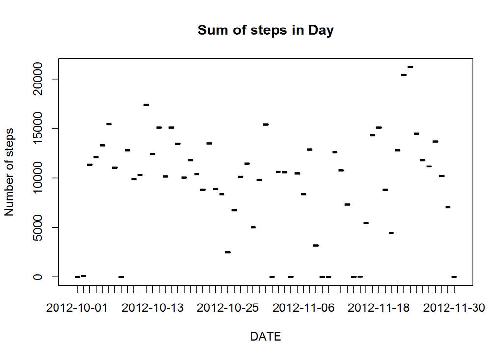

```r
dates <- group_by(data_pac, date)

data_sum_step <- summarise(dates, steps_in_day = sum(steps, na.rm = TRUE))
plot(data_sum_step$date, data_sum_step$steps_in_day, type = "l", xlab="DATE", ylab="Number of steps", main = "Sum of steps in Day")
```

### Make a histogram of the total number of steps taken each day

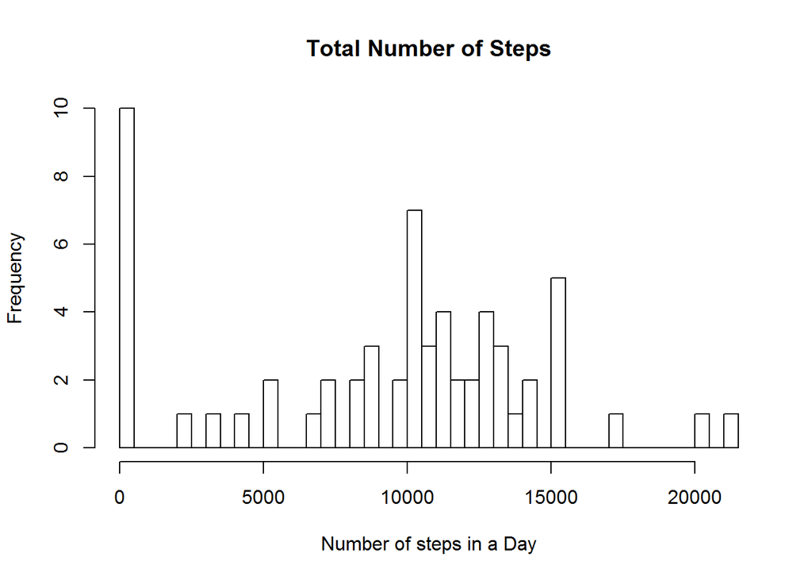

```r
hist(data_sum_step$steps_in_day, breaks = 50, xlab = "Number of steps in a Day", ylab = "Frequency", main = "Total Number of Steps")
```

```r
#number of breaks is chosen for better distinguishability
```

### Calculate and report the mean and median of the total number of steps taken per day

```r
mean_total_no_steps <- mean(data_sum_step$steps_in_day)
median_total_no_steps <- median(data_sum_step$steps_in_day)
```

Mean number of steps = 9354.2295082

Median number of steps = 10395

# PART 02

## What is the average daily activity pattern?

### Time series plot of the 5-minute interval and the average number of steps taken, averaged across all days

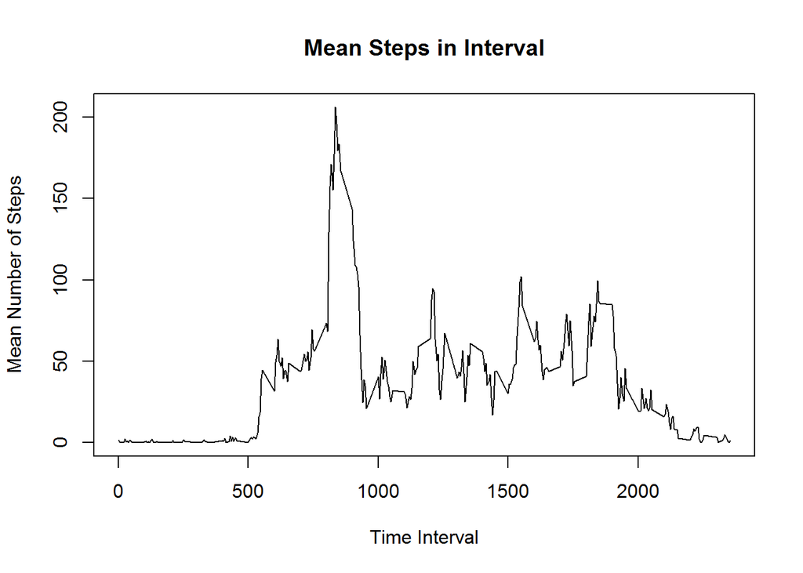

```r
data_intervals <- group_by(data_pac, interval)

data_mean_interval <- summarise(data_intervals, steps_in_interval = mean(steps, na.rm = TRUE))
plot(data_mean_interval$interval, data_mean_interval$steps_in_interval, type = "l", xlab = "Time Interval", ylab = "Mean Number of Steps", main = "Mean Steps in Interval")
```

### Which 5-minute interval, on average across all the days in the dataset, contains the maximum number of steps?

```r
max_steps_interval_index <- which.max(data_mean_interval$steps_in_interval)
max_steps_interval_value <- data_mean_interval$interval[max_steps_interval_index]
```

5-minute interval containing max number steps = 835

# PART 03

### Imputing the missing valus

```r
new_DF <- data_pac[rowSums(is.na(data_pac)) > 0,]
number_of_rows_without_NA <- nrow(new_DF)
```

Total number of missing values in the dataset = 2304

### Create a new dataset that is equal to the original dataset but with the missing data filled in.

```r
impute_data_pac <- data_pac

impute_data_pac$steps <- impute(data_pac$steps, fun=mean)
```

impute_data_pac is the new data